# More Split-Apply-Combine

Here I will reemphasize that learning how to think about working with data is more important than learning how to use specific tools. You can use the `dplyr` package to get the same results as with `plyr` but in a slightly different way.

`dplyr` implements the following verbs useful for data manipulation:

`select()`: focus on a subset of variables  
`filter()`: focus on a subset of rows  
`mutate()`: add new columns  
`summarise()`: reduce each group to a smaller number of summary statistics  
`arrange()`: re-order the rows  
`do()`: applies any R function to each group of the data

Here we take our data, use the`group_by` function to do the splitting and then `summarise` each group with a function (here we take the mean of gdpPercap).

```r
library(dplyr)
grouped_gap<-group_by(gapminder,continent)
summarise(grouped_gap,gdp = mean(gdpPercap))
```

```
## # A tibble: 5 × 2
##   continent       gdp
##      <fctr>     <dbl>
## 1    Africa  2193.755
## 2  Americas  7136.110
## 3      Asia  7902.150
## 4    Europe 14469.476
## 5   Oceania 18621.609
```

The way I have written the commands above works, but it difficult to read. The `%>%` works as a pipe in R the way that `|` did in bash. It loads with `dplyr` or the `magrittr` package. We can pipe the data to `group_by` and then pipe that to `summarise`, which makes our workflow more readable. You usually to need to group prior to summarising. You can also group by more than one variable.

```r
gapminder %>% group_by(continent) %>% summarise(gdp = mean(gdpPercap))
```

```
## # A tibble: 5 × 2
##   continent       gdp
##      <fctr>     <dbl>
## 1    Africa  2193.755
## 2  Americas  7136.110
## 3      Asia  7902.150
## 4    Europe 14469.476
## 5   Oceania 18621.609
```

Note this is a tibble, which is “a modern reimagining of the data.frame, keeping what time has proven to be effective, and throwing out what is not.” The result is the same as when we used `dlply` previously.

You can even use pipes to send your results to `ggplot` directly.

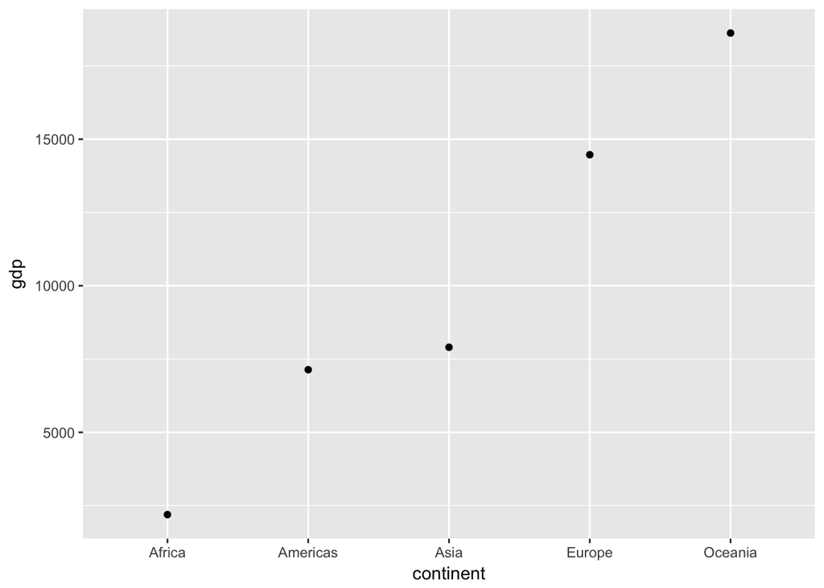

```r
gapminder %>% group_by(continent) %>% summarise(gdp = mean(gdpPercap)) %>%
  ggplot(aes(x=continent,y=gdp))+geom_point()
```

Here is an example of `filter`ing - note the simplicity compared to our previous approach to subset data.

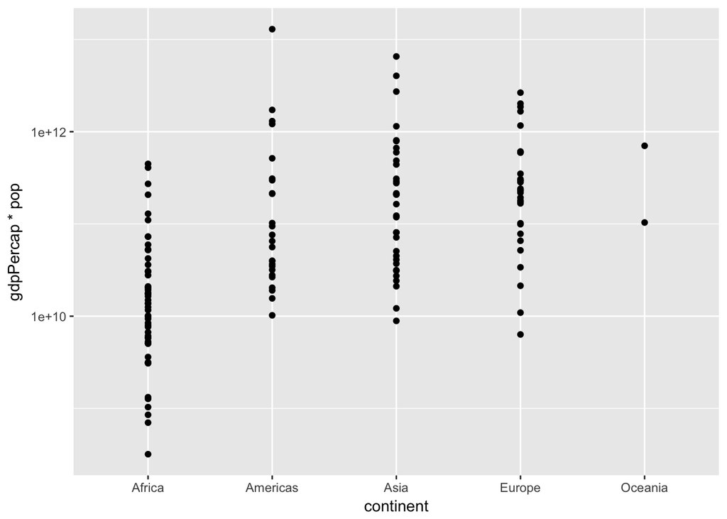

```r
gapminder %>% filter(year==2007) %>%
  ggplot(aes(x=continent,y=gdpPercap*pop))+geom_point()+scale_y_log10()
```

Here is an example of using `mutate` and sending the resulting output into the pipe, rather than calculating the y value when ggplot is called.

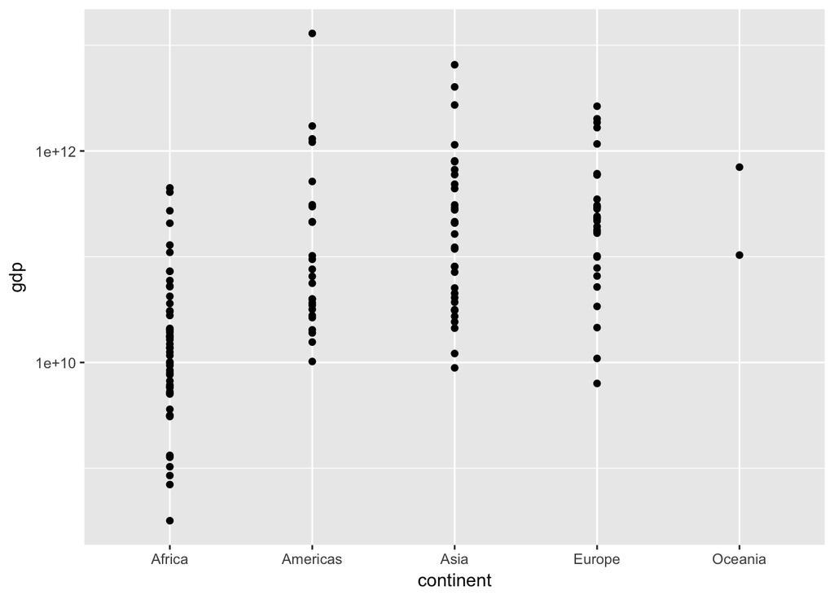

```r
mutate(gapminder,gdp=gdpPercap*pop) %>% filter(year==2007) %>%
  ggplot(aes(x=continent,y=gdp))+geom_point()+scale_y_log10()
```

*Some of this material was taken from the `dplyr` github readme.*